# Evolutionary Genomics Lab 3

#### Using masks to identify a specific condition

*A mask can be useful to locate where a particular subset of values exist or don’t exist - for example, NaN, or “Not a Number” values. To understand masks, we also need to understand **BOOLEAN** objects in Python.*

*Boolean values include **True** or **False**.*

```python
# Set X to 5
x = 5
```

```python
# What does the code below return?
x < 5
```

```
False
```

```python
# How about this?
x == 5
```

```
True
```

```python
# identify locations where missing/null data exists using 'isnull'.
pd.isnull(surveys_df)
```

|  | record_id | month | day | year | plot_id | species_id | sex | hindfoot_length | weight |
| --- | --- | --- | --- | --- | --- | --- | --- | --- | --- |
| 0 | False | False | False | False | False | False | False | False | True |
| 1 | False | False | False | False | False | False | False | False | True |
| 2 | False | False | False | False | False | False | False | False | True |
| 3 | False | False | False | False | False | False | False | False | True |
| 4 | False | False | False | False | False | False | False | False | True |
| ... | ... | ... | ... | ... | ... | ... | ... | ... | ... |
| 35544 | False | False | False | False | False | False | True | True | True |
| 35545 | False | False | False | False | False | False | True | True | True |
| 35546 | False | False | False | False | False | False | False | False | False |
| 35547 | False | False | False | False | False | False | False | False | False |
| 35548 | False | False | False | False | False | True | True | True | True |

35549 rows × 9 columns

```python
# Select just the rows with NaN values using 'any()'
surveys_df[pd.isnull(surveys_df).any(axis=1)]
```

|  | record_id | month | day | year | plot_id | species_id | sex | hindfoot_length | weight |
| --- | --- | --- | --- | --- | --- | --- | --- | --- | --- |
| 0 | 1 | 7 | 16 | 1977 | 2 | NL | M | 32.0 | NaN |
| 1 | 2 | 7 | 16 | 1977 | 3 | NL | M | 33.0 | NaN |
| 2 | 3 | 7 | 16 | 1977 | 2 | DM | F | 37.0 | NaN |
| 3 | 4 | 7 | 16 | 1977 | 7 | DM | M | 36.0 | NaN |
| 4 | 5 | 7 | 16 | 1977 | 3 | DM | M | 35.0 | NaN |
| ... | ... | ... | ... | ... | ... | ... | ... | ... | ... |
| 35530 | 35531 | 12 | 31 | 2002 | 13 | PB | F | 27.0 | NaN |
| 35543 | 35544 | 12 | 31 | 2002 | 15 | US | NaN | NaN | NaN |
| 35544 | 35545 | 12 | 31 | 2002 | 15 | AH | NaN | NaN | NaN |
| 35545 | 35546 | 12 | 31 | 2002 | 15 | AH | NaN | NaN | NaN |
| 35548 | 35549 | 12 | 31 | 2002 | 5 | NaN | NaN | NaN | NaN |

4873 rows × 9 columns

```python
# What does the following do? Selects for rows with NaN values in weight column
empty_weights = surveys_df[pd.isnull(surveys_df['weight'])]['weight']
print(empty_weights)
```

```
0       NaN
1       NaN
2       NaN
3       NaN
4       NaN
         ..
35530   NaN
35543   NaN
35544   NaN
35545   NaN
35548   NaN
Name: weight, Length: 3266, dtype: float64
```

**Challenge - Putting it all together**

1. Create new DataFrame that only contains observations with sex values that are not female or male. Assign each sex value in the new DataFrame to a new value of ‘x’. Determine the number of null values in the subset.
2. Create a new DataFrame that contains only observations that are of sex male or female and where weight values are greater than 0. Create a stacked bar plot of average weight by plot with male vs female values stacked for each plot.

```python
surveys_copy = surveys_df.copy()
surveys_copy_not_mf = surveys_copy[~(surveys_copy.sex == 'M') & ~(surveys_copy.sex == 'F')]
surveys_copy_not_mf.head(10)
```

|  | record_id | month | day | year | plot_id | species_id | sex | hindfoot_length | weight |
| --- | --- | --- | --- | --- | --- | --- | --- | --- | --- |
| 13 | 14 | 7 | 16 | 1977 | 8 | DM | NaN | NaN | NaN |
| 18 | 19 | 7 | 16 | 1977 | 4 | PF | NaN | NaN | NaN |
| 33 | 34 | 7 | 17 | 1977 | 17 | DM | NaN | NaN | NaN |
| 56 | 57 | 7 | 18 | 1977 | 22 | DM | NaN | NaN | NaN |
| 76 | 77 | 8 | 19 | 1977 | 4 | SS | NaN | NaN | NaN |
| 92 | 93 | 8 | 20 | 1977 | 18 | DM | NaN | NaN | 42.0 |
| 105 | 106 | 8 | 20 | 1977 | 12 | NL | NaN | NaN | NaN |
| 106 | 107 | 8 | 20 | 1977 | 18 | NL | NaN | NaN | NaN |
| 109 | 110 | 8 | 20 | 1977 | 10 | DS | NaN | NaN | NaN |
| 120 | 121 | 8 | 21 | 1977 | 15 | NL | NaN | NaN | NaN |

```python
surveys_copy_not_mf.loc[:, ['sex']] = 'x'
surveys_copy_not_mf
```

|  | record_id | month | day | year | plot_id | species_id | sex | hindfoot_length | weight |
| --- | --- | --- | --- | --- | --- | --- | --- | --- | --- |
| 13 | 14 | 7 | 16 | 1977 | 8 | DM | x | NaN | NaN |
| 18 | 19 | 7 | 16 | 1977 | 4 | PF | x | NaN | NaN |
| 33 | 34 | 7 | 17 | 1977 | 17 | DM | x | NaN | NaN |
| 56 | 57 | 7 | 18 | 1977 | 22 | DM | x | NaN | NaN |
| 76 | 77 | 8 | 19 | 1977 | 4 | SS | x | NaN | NaN |
| ... | ... | ... | ... | ... | ... | ... | ... | ... | ... |
| 35527 | 35528 | 12 | 31 | 2002 | 13 | US | x | NaN | NaN |
| 35543 | 35544 | 12 | 31 | 2002 | 15 | US | x | NaN | NaN |
| 35544 | 35545 | 12 | 31 | 2002 | 15 | AH | x | NaN | NaN |
| 35545 | 35546 | 12 | 31 | 2002 | 15 | AH | x | NaN | NaN |
| 35548 | 35549 | 12 | 31 | 2002 | 5 | NaN | x | NaN | NaN |

2511 rows × 9 columns

```python
# answer for challenge 1
surveys_copy_not_mf.isnull().sum().sum()
```

```
5616
```

```python
surveys_copy = surveys_df.copy()
surveys_copy_mf = surveys_copy[(surveys_copy.sex == 'M') | (surveys_copy.sex == 'F')][(surveys_copy.weight > 0)]
surveys_copy_mf
```

|  | record_id | month | day | year | plot_id | species_id | sex | hindfoot_length | weight |
| --- | --- | --- | --- | --- | --- | --- | --- | --- | --- |
| 62 | 63 | 8 | 19 | 1977 | 3 | DM | M | 35.0 | 40.0 |
| 63 | 64 | 8 | 19 | 1977 | 7 | DM | M | 37.0 | 48.0 |
| 64 | 65 | 8 | 19 | 1977 | 4 | DM | F | 34.0 | 29.0 |
| 65 | 66 | 8 | 19 | 1977 | 4 | DM | F | 35.0 | 46.0 |
| 66 | 67 | 8 | 19 | 1977 | 7 | DM | M | 35.0 | 36.0 |
| ... | ... | ... | ... | ... | ... | ... | ... | ... | ... |
| 35540 | 35541 | 12 | 31 | 2002 | 15 | PB | F | 24.0 | 31.0 |
| 35541 | 35542 | 12 | 31 | 2002 | 15 | PB | F | 26.0 | 29.0 |
| 35542 | 35543 | 12 | 31 | 2002 | 15 | PB | F | 27.0 | 34.0 |
| 35546 | 35547 | 12 | 31 | 2002 | 10 | RM | F | 15.0 | 14.0 |
| 35547 | 35548 | 12 | 31 | 2002 | 7 | DO | M | 36.0 | 51.0 |

32182 rows × 9 columns

```python
stacked_by_sex = surveys_df.groupby(['plot_id', 'sex'])['weight'].sum().unstack()
plot = stacked_by_sex.plot.bar(stacked=True, title="Total weight by site and sex")
plot.set_ylabel("Weight")
plot.set_xlabel("Plot")
```

[output not shown]

```python
stacked_by_sex = surveys_copy_mf.groupby(['plot_id', 'sex'])['weight'].mean().unstack()
stacked_by_sex.head()
```

| sex plot_id | F | M |
| --- | --- | --- |
| 1 | 46.311138 | 55.950560 |
| 2 | 52.561845 | 51.391382 |
| 3 | 31.215349 | 34.163241 |
| 4 | 46.818824 | 48.888119 |
| 5 | 40.974806 | 40.708551 |

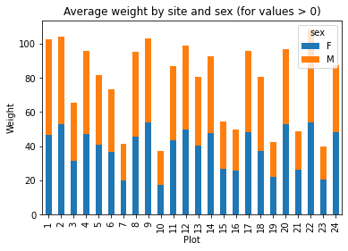

```python
plot = stacked_by_sex.plot.bar(stacked=True, title="Average weight by site and sex (for values > 0)")
plot.set_ylabel("Weight")
plot.set_xlabel("Plot")
```

**Key Points from Lesson 2: Indexing, Slicing and Subsetting DataFrames in Python**

- In Python, portions of data can be accessed using indices, slices, column headings, and condition-based subsetting.
- Python uses 0-based indexing, in which the first element in a list, tuple or any other data structure has an index of 0.
- Pandas enables common data exploration steps such as data indexing, slicing and conditional subsetting.

### Lesson 3: Data Types and Formats

**Lesson Questions**

- What types of data can be contained in a DataFrame?
- Why is the data type important?

**Lesson Objectives**

- Describe how information is stored in a Python DataFrame.
- Define the two main types of data in Python: text and numerics.
- Examine the structure of a DataFrame.
- Modify the format of values in a DataFrame.
- Describe how data types impact operations.
- Define, manipulate, and interconvert integers and floats in Python.
- Analyze datasets having missing/null values (NaN values).
- Write manipulated data to a file.

```python
# Set working directory

import os
os.chdir('/Users/greg/Box/courses/umass/fall-2020/evolutionary-genomics-and-bioinformatics/evo-geno-course/')
os.getcwd()
```

```
'/Users/greg/Box/courses/umass/fall-2020/evolutionary-genomics-and-bioinformatics/evo-geno-course'
```

#### Checking the format of our data

```python
import pandas as pd
```

```python
surveys_df = pd.read_csv("data/lab-3-data/surveys.csv")
```

```python
type(surveys_df)
```

```
pandas.core.frame.DataFrame
```

```python
surveys_df['sex'].dtype
```

```
dtype('O')
```

**Note: 'O' stands for object or string/text**

```python
surveys_df['record_id'].dtype
```

```
dtype('int64')
```

```python
surveys_df.dtypes
```

```
record_id            int64
month                int64
day                  int64
year                 int64
plot_id              int64
species_id          object
sex                 object
hindfoot_length    float64
weight             float64
dtype: object
```

**Note: the 64 stands for 64-bits. Python stores each value as a 64-bit integer or float. Float = decimal number.

#### Working with Integers and Floats

```python
print(5+5)
```

```
10
```

```python
print(24-4)
```

```
20
```

```python
print(5/9)
```

```
0.5555555555555556
```

```python
print(10/3)
```

```
3.3333333333333335
```

```python
# Convert a to an integer
a = 7.83
int(a)
```

```
7
```

```python
# Convert b to a float
b = 7
float(b)
```

```
7.0
```

#### Working with our Survey Data

```python
# Convert the record_id field from an integer to a float
surveys_df['record_id'] = surveys_df['record_id'].astype('float64')
surveys_df['record_id'].dtype
```

```
dtype('float64')
```

```python
# Convert plot_id to a float
surveys_df.plot_id.astype("float")
```

```
0         2.0
1         3.0
2         2.0
3         7.0
4         3.0
         ...
35544    15.0
35545    15.0
35546    10.0
35547     7.0
35548     5.0
Name: plot_id, Length: 35549, dtype: float64
```

```python
# Convert weight to an integer
surveys_df.weight.astype("int")
```

```
---------------------------------------------------------------------------
ValueError                                Traceback (most recent call last)
<ipython-input-249-38a2a5c7b7f2> in <module>
      1 # Convert weight to an integer
----> 2 surveys_df.weight.astype("int")

~/opt/anaconda3/lib/python3.8/site-packages/pandas/core/generic.py in astype(self, dtype, copy, errors)
   5696         else:
   5697             # else, only a single dtype is given
-> 5698             new_data = self._data.astype(dtype=dtype, copy=copy, errors=errors)
   5699             return self._constructor(new_data).__finalize__(self)
   5700

~/opt/anaconda3/lib/python3.8/site-packages/pandas/core/internals/managers.py in astype(self, dtype, copy, errors)
    580
    581     def astype(self, dtype, copy: bool = False, errors: str = "raise"):
--> 582         return self.apply("astype", dtype=dtype, copy=copy, errors=errors)
    583
    584     def convert(self, **kwargs):

~/opt/anaconda3/lib/python3.8/site-packages/pandas/core/internals/managers.py in apply(self, f, filter, **kwargs)
    440                 applied = b.apply(f, **kwargs)
    441             else:
--> 442                 applied = getattr(b, f)(**kwargs)
    443             result_blocks = _extend_blocks(applied, result_blocks)
    444

~/opt/anaconda3/lib/python3.8/site-packages/pandas/core/internals/blocks.py in astype(self, dtype, copy, errors)
    623             vals1d = values.ravel()
    624             try:
--> 625                 values = astype_nansafe(vals1d, dtype, copy=True)
    626             except (ValueError, TypeError):
    627                 # e.g. astype_nansafe can fail on object-dtype of strings

~/opt/anaconda3/lib/python3.8/site-packages/pandas/core/dtypes/cast.py in astype_nansafe(arr, dtype, copy, skipna)
    866
    867         if not np.isfinite(arr).all():
--> 868             raise ValueError("Cannot convert non-finite values (NA or inf) to integer")
    869
    870     elif is_object_dtype(arr):

ValueError: Cannot convert non-finite values (NA or inf) to integer
```

**Note: The problem here is that there are NaNs in the column. NaNs cannot be converted to integers**

#### Missing Data Values - NaN

```python
# Python knows to skip over NaN (Not a Number cells when calculating)
surveys_df['weight'].mean()
```

```
42.672428212991356
```

#### Where are the NaNs

```python
# How many rows have NaNs as weight values?
len(surveys_df[pd.isnull(surveys_df.weight)])
```

```
3266
```

```python
# How many rows have weight values?
len(surveys_df[surveys_df.weight > 0])
```

```
32283
```

```python
df1 = surveys_df.copy()

# Fill all NaN values with 0
df1['weight'] = df1['weight'].fillna(0)
df1['weight'].mean()
```

```
38.751976145601844
```

```python
# Fill all NaN values with a mean for all weight values
df1['weight'] = surveys_df['weight'].fillna(surveys_df['weight'].mean())
```

```python
# Count the number of missing values per column
surveys_df.isnull().sum()
```

```
record_id             0
month                 0
day                   0
year                  0
plot_id               0
species_id          763
sex                2511
hindfoot_length    4111
weight             3266
dtype: int64
```

#### Writing out data to CSV

```python
surveys_df = pd.read_csv("data/lab-3-data/surveys.csv")
```

```python
# Drop all rows containing missing values
df_na = surveys_df.dropna()
```

We can now use the to_csv command to export a DataFrame in CSV format. We use ‘index=False’ so that pandas doesn’t include the index number for each line.

```python
# Write DataFrame to CSV
df_na.to_csv('data/lab-3-data/surveys_complete.csv', index=False)
```

**Key Points from Lesson 3: Data Types and Formats**

- Pandas uses other names for data types than Python, for example: object for textual data.
- A column in a DataFrame can only have one data type.
- The data type in a DataFrame’s single column can be checked using dtype.
- Make conscious decisions about how to manage missing data.
- A DataFrame can be saved to a CSV file using the to_csv function.

### Lesson 4: Combining DataFrames with Pandas

**Lesson Questions**

- Can I work with data from multiple sources?
- How can I combine data from different data sets?

**Lesson Objectives**

- Combine data from multiple files into a single DataFrame using merge and concat.
- Combine two DataFrames using a unique ID found in both DataFrames.
- Employ to_csv to export a DataFrame in CSV format.
- Join DataFrames using common fields (join keys).

```python
# Set working directory

import os
os.chdir('/Users/greg/Box/courses/umass/fall-2020/evolutionary-genomics-and-bioinformatics/evo-geno-course/')
os.getcwd()
```

```
'/Users/greg/Box/courses/umass/fall-2020/evolutionary-genomics-and-bioinformatics/evo-geno-course'
```

*In many “real world” situations, the data that we want to use come in multiple files. We often need to combine these files into a single DataFrame to analyze the data. The pandas package provides various methods for combining DataFrames including **merge** and **concat**.*

```python
import pandas as pd
surveys_df = pd.read_csv("data/lab-3-data/surveys.csv",
                        keep_default_na=False, na_values=[""])
surveys_df
```

|  | record_id | month | day | year | plot_id | species_id | sex | hindfoot_length | weight |
| --- | --- | --- | --- | --- | --- | --- | --- | --- | --- |
| 0 | 1 | 7 | 16 | 1977 | 2 | NL | M | 32.0 | NaN |
| 1 | 2 | 7 | 16 | 1977 | 3 | NL | M | 33.0 | NaN |
| 2 | 3 | 7 | 16 | 1977 | 2 | DM | F | 37.0 | NaN |
| 3 | 4 | 7 | 16 | 1977 | 7 | DM | M | 36.0 | NaN |
| 4 | 5 | 7 | 16 | 1977 | 3 | DM | M | 35.0 | NaN |
| ... | ... | ... | ... | ... | ... | ... | ... | ... | ... |
| 35544 | 35545 | 12 | 31 | 2002 | 15 | AH | NaN | NaN | NaN |
| 35545 | 35546 | 12 | 31 | 2002 | 15 | AH | NaN | NaN | NaN |
| 35546 | 35547 | 12 | 31 | 2002 | 10 | RM | F | 15.0 | 14.0 |
| 35547 | 35548 | 12 | 31 | 2002 | 7 | DO | M | 36.0 | 51.0 |
| 35548 | 35549 | 12 | 31 | 2002 | 5 | NaN | NaN | NaN | NaN |

35549 rows × 9 columns

Read more about all of the read_csv options [here](https://pandas.pydata.org/pandas-docs/stable/reference/api/pandas.read_csv.html#pandas.read_csv).

```python
species_df = pd.read_csv("data/lab-3-data/species.csv",
                        keep_default_na=False, na_values=[""])
species_df.head(10)
```

|  | species_id | genus | species | taxa |
| --- | --- | --- | --- | --- |
| 0 | AB | Amphispiza | bilineata | Bird |
| 1 | AH | Ammospermophilus | harrisi | Rodent |
| 2 | AS | Ammodramus | savannarum | Bird |
| 3 | BA | Baiomys | taylori | Rodent |
| 4 | CB | Campylorhynchus | brunneicapillus | Bird |
| 5 | CM | Calamospiza | melanocorys | Bird |
| 6 | CQ | Callipepla | squamata | Bird |
| 7 | CS | Crotalus | scutalatus | Reptile |
| 8 | CT | Cnemidophorus | tigris | Reptile |
| 9 | CU | Cnemidophorus | uniparens | Reptile |

#### Concatenating DataFrames

```python
# Read in first 10 lines of surveys table
survey_sub = surveys_df.head(10)
```

```python
# Grab last 10 rows
survey_sub_last10 = surveys_df.tail(10)
```

```python
# Reset the index values to the second dataframe appends properly
survey_sub_last10 = survey_sub_last10.reset_index(drop=True)
```

**drop=True** option avoids adding new index column with old index values

```python
# Stack the DataFrames on top of each other
vertical_stack = pd.concat([survey_sub, survey_sub_last10], axis=0)
```

```python
# Place the DataFrames side by side
horizontal_stack = pd.concat([survey_sub, survey_sub_last10], axis=1)
```

*When we concatenate DataFrames, we need to specify the axis. **axis=0** tells pandas to stack the second DataFrame UNDER the first one. It will automatically detect whether the column names are the same and will stack accordingly. **axis=1** will stack the columns in the second DataFrame to the RIGHT of the first DataFrame. To stack the data vertically, we need to make sure we have the same columns and associated column format in both datasets. When we stack horizontally, we want to make sure what we are doing makes sense (i.e. the data are related in some way).*

#### Row Index Values and Concat

```python
# Have a look at the vertical stack dataframe
vertical_stack
```

|  | record_id | month | day | year | plot_id | species_id | sex | hindfoot_length | weight |
| --- | --- | --- | --- | --- | --- | --- | --- | --- | --- |
| 0 | 1 | 7 | 16 | 1977 | 2 | NL | M | 32.0 | NaN |
| 1 | 2 | 7 | 16 | 1977 | 3 | NL | M | 33.0 | NaN |
| 2 | 3 | 7 | 16 | 1977 | 2 | DM | F | 37.0 | NaN |
| 3 | 4 | 7 | 16 | 1977 | 7 | DM | M | 36.0 | NaN |
| 4 | 5 | 7 | 16 | 1977 | 3 | DM | M | 35.0 | NaN |
| 5 | 6 | 7 | 16 | 1977 | 1 | PF | M | 14.0 | NaN |
| 6 | 7 | 7 | 16 | 1977 | 2 | PE | F | NaN | NaN |
| 7 | 8 | 7 | 16 | 1977 | 1 | DM | M | 37.0 | NaN |
| 8 | 9 | 7 | 16 | 1977 | 1 | DM | F | 34.0 | NaN |
| 9 | 10 | 7 | 16 | 1977 | 6 | PF | F | 20.0 | NaN |
| 0 | 35540 | 12 | 31 | 2002 | 15 | PB | F | 26.0 | 23.0 |
| 1 | 35541 | 12 | 31 | 2002 | 15 | PB | F | 24.0 | 31.0 |
| 2 | 35542 | 12 | 31 | 2002 | 15 | PB | F | 26.0 | 29.0 |
| 3 | 35543 | 12 | 31 | 2002 | 15 | PB | F | 27.0 | 34.0 |
| 4 | 35544 | 12 | 31 | 2002 | 15 | US | NaN | NaN | NaN |
| 5 | 35545 | 12 | 31 | 2002 | 15 | AH | NaN | NaN | NaN |
| 6 | 35546 | 12 | 31 | 2002 | 15 | AH | NaN | NaN | NaN |
| 7 | 35547 | 12 | 31 | 2002 | 10 | RM | F | 15.0 | 14.0 |
| 8 | 35548 | 12 | 31 | 2002 | 7 | DO | M | 36.0 | 51.0 |
| 9 | 35549 | 12 | 31 | 2002 | 5 | NaN | NaN | NaN | NaN |

**Note: row indexes for the two DataFrames have been repeated**

```python
# Reset indexes
vertical_stack.reset_index(drop=True)
```

|  | record_id | month | day | year | plot_id | species_id | sex | hindfoot_length | weight |
| --- | --- | --- | --- | --- | --- | --- | --- | --- | --- |
| 0 | 1 | 7 | 16 | 1977 | 2 | NL | M | 32.0 | NaN |
| 1 | 2 | 7 | 16 | 1977 | 3 | NL | M | 33.0 | NaN |
| 2 | 3 | 7 | 16 | 1977 | 2 | DM | F | 37.0 | NaN |
| 3 | 4 | 7 | 16 | 1977 | 7 | DM | M | 36.0 | NaN |
| 4 | 5 | 7 | 16 | 1977 | 3 | DM | M | 35.0 | NaN |
| 5 | 6 | 7 | 16 | 1977 | 1 | PF | M | 14.0 | NaN |
| 6 | 7 | 7 | 16 | 1977 | 2 | PE | F | NaN | NaN |
| 7 | 8 | 7 | 16 | 1977 | 1 | DM | M | 37.0 | NaN |
| 8 | 9 | 7 | 16 | 1977 | 1 | DM | F | 34.0 | NaN |
| 9 | 10 | 7 | 16 | 1977 | 6 | PF | F | 20.0 | NaN |
| 10 | 35540 | 12 | 31 | 2002 | 15 | PB | F | 26.0 | 23.0 |
| 11 | 35541 | 12 | 31 | 2002 | 15 | PB | F | 24.0 | 31.0 |
| 12 | 35542 | 12 | 31 | 2002 | 15 | PB | F | 26.0 | 29.0 |
| 13 | 35543 | 12 | 31 | 2002 | 15 | PB | F | 27.0 | 34.0 |
| 14 | 35544 | 12 | 31 | 2002 | 15 | US | NaN | NaN | NaN |
| 15 | 35545 | 12 | 31 | 2002 | 15 | AH | NaN | NaN | NaN |
| 16 | 35546 | 12 | 31 | 2002 | 15 | AH | NaN | NaN | NaN |
| 17 | 35547 | 12 | 31 | 2002 | 10 | RM | F | 15.0 | 14.0 |
| 18 | 35548 | 12 | 31 | 2002 | 7 | DO | M | 36.0 | 51.0 |
| 19 | 35549 | 12 | 31 | 2002 | 5 | NaN | NaN | NaN | NaN |

#### Writing out Data to CSV

```python
# Write DataFrame to CSV
vertical_stack.to_csv('data/lab-3-data/out.csv', index=False)
```

```python
# Read output back into Python and make sure it looks good
new_output = pd.read_csv('data/lab-3-data/out.csv',
                        keep_default_na=False, na_values=[""])
new_output
```

|  | record_id | month | day | year | plot_id | species_id | sex | hindfoot_length | weight |
| --- | --- | --- | --- | --- | --- | --- | --- | --- | --- |
| 0 | 1 | 7 | 16 | 1977 | 2 | NL | M | 32.0 | NaN |
| 1 | 2 | 7 | 16 | 1977 | 3 | NL | M | 33.0 | NaN |
| 2 | 3 | 7 | 16 | 1977 | 2 | DM | F | 37.0 | NaN |
| 3 | 4 | 7 | 16 | 1977 | 7 | DM | M | 36.0 | NaN |
| 4 | 5 | 7 | 16 | 1977 | 3 | DM | M | 35.0 | NaN |
| 5 | 6 | 7 | 16 | 1977 | 1 | PF | M | 14.0 | NaN |
| 6 | 7 | 7 | 16 | 1977 | 2 | PE | F | NaN | NaN |
| 7 | 8 | 7 | 16 | 1977 | 1 | DM | M | 37.0 | NaN |
| 8 | 9 | 7 | 16 | 1977 | 1 | DM | F | 34.0 | NaN |
| 9 | 10 | 7 | 16 | 1977 | 6 | PF | F | 20.0 | NaN |
| 10 | 35540 | 12 | 31 | 2002 | 15 | PB | F | 26.0 | 23.0 |
| 11 | 35541 | 12 | 31 | 2002 | 15 | PB | F | 24.0 | 31.0 |
| 12 | 35542 | 12 | 31 | 2002 | 15 | PB | F | 26.0 | 29.0 |
| 13 | 35543 | 12 | 31 | 2002 | 15 | PB | F | 27.0 | 34.0 |
| 14 | 35544 | 12 | 31 | 2002 | 15 | US | NaN | NaN | NaN |
| 15 | 35545 | 12 | 31 | 2002 | 15 | AH | NaN | NaN | NaN |
| 16 | 35546 | 12 | 31 | 2002 | 15 | AH | NaN | NaN | NaN |
| 17 | 35547 | 12 | 31 | 2002 | 10 | RM | F | 15.0 | 14.0 |
| 18 | 35548 | 12 | 31 | 2002 | 7 | DO | M | 36.0 | 51.0 |
| 19 | 35549 | 12 | 31 | 2002 | 5 | NaN | NaN | NaN | NaN |

**Challenge - Combine Data**

- Combine surveys2001 and surveys2002
- Create plot of average plot weight by year grouped by sex
- Export results as a CSV
- Make sure CSV reads back properly

```python
surveys2001 = pd.read_csv("data/lab-3-data/surveys2001.csv")
surveys2002 = pd.read_csv("data/lab-3-data/surveys2002.csv")
```

```python
surveys2001.head()
```

|  | Unnamed: 0 | record_id | month | day | year | site_id | species_id | sex | hindfoot_length | weight |
| --- | --- | --- | --- | --- | --- | --- | --- | --- | --- | --- |
| 0 | 31710 | 31711 | 1 | 21 | 2001 | 1 | PB | F | 26.0 | 25.0 |
| 1 | 31711 | 31712 | 1 | 21 | 2001 | 1 | DM | M | 37.0 | 43.0 |
| 2 | 31712 | 31713 | 1 | 21 | 2001 | 1 | PB | M | 29.0 | 44.0 |
| 3 | 31713 | 31714 | 1 | 21 | 2001 | 1 | DO | M | 34.0 | 53.0 |
| 4 | 31714 | 31715 | 1 | 21 | 2001 | 2 | OT | M | 20.0 | 27.0 |

```python
surveys2002.tail()
```

|  | Unnamed: 0 | record_id | month | day | year | site_id | species_id | sex | hindfoot_length | weight |
| --- | --- | --- | --- | --- | --- | --- | --- | --- | --- | --- |
| 2073 | 35540 | 35541 | 12 | 31 | 2002 | 15 | PB | F | 24.0 | 31.0 |
| 2074 | 35541 | 35542 | 12 | 31 | 2002 | 15 | PB | F | 26.0 | 29.0 |
| 2075 | 35542 | 35543 | 12 | 31 | 2002 | 15 | PB | F | 27.0 | 34.0 |
| 2076 | 35546 | 35547 | 12 | 31 | 2002 | 10 | RM | F | 15.0 | 14.0 |
| 2077 | 35547 | 35548 | 12 | 31 | 2002 | 7 | DO | M | 36.0 | 51.0 |

```python
# Combine surveys2001 and surveys2002
stack_surveys = pd.concat([surveys2001, surveys2002], axis=0)
stack_surveys
```

|  | Unnamed: 0 | record_id | month | day | year | site_id | species_id | sex | hindfoot_length | weight |
| --- | --- | --- | --- | --- | --- | --- | --- | --- | --- | --- |
| 0 | 31710 | 31711 | 1 | 21 | 2001 | 1 | PB | F | 26.0 | 25.0 |
| 1 | 31711 | 31712 | 1 | 21 | 2001 | 1 | DM | M | 37.0 | 43.0 |
| 2 | 31712 | 31713 | 1 | 21 | 2001 | 1 | PB | M | 29.0 | 44.0 |
| 3 | 31713 | 31714 | 1 | 21 | 2001 | 1 | DO | M | 34.0 | 53.0 |
| 4 | 31714 | 31715 | 1 | 21 | 2001 | 2 | OT | M | 20.0 | 27.0 |
| ... | ... | ... | ... | ... | ... | ... | ... | ... | ... | ... |
| 2073 | 35540 | 35541 | 12 | 31 | 2002 | 15 | PB | F | 24.0 | 31.0 |
| 2074 | 35541 | 35542 | 12 | 31 | 2002 | 15 | PB | F | 26.0 | 29.0 |
| 2075 | 35542 | 35543 | 12 | 31 | 2002 | 15 | PB | F | 27.0 | 34.0 |
| 2076 | 35546 | 35547 | 12 | 31 | 2002 | 10 | RM | F | 15.0 | 14.0 |
| 2077 | 35547 | 35548 | 12 | 31 | 2002 | 7 | DO | M | 36.0 | 51.0 |

3512 rows × 10 columns

```python
plot = stacked_by_sex.plot.bar(stacked=True, title="Average weight by site and sex (for values > 0)")
plot.set_ylabel("Weight")
plot.set_xlabel("Plot")
```

[figure not shown]

```python
# Create plot of average plot weight by year grouped by sex

stack_surveys_2 = stack_surveys.groupby(['site_id', 'year','sex'])['weight'].mean().unstack().unstack()
plot = stack_surveys_2.plot.bar(stacked=False, title="Average plot weight by year and sex")
plot.set_ylabel("Weight")
plot.set_xlabel("Plot")
```

```python
# Export results as a CSV
stack_surveys.to_csv('data/lab-3-data/stack_surveys.csv', index=False)
# Make sure CSV reads back properly
new_stack_surveys = pd.read_csv('data/lab-3-data/stack_surveys.csv')
new_stack_surveys
```

|  | Unnamed: 0 | record_id | month | day | year | site_id | species_id | sex | hindfoot_length | weight |
| --- | --- | --- | --- | --- | --- | --- | --- | --- | --- | --- |
| 0 | 31710 | 31711 | 1 | 21 | 2001 | 1 | PB | F | 26.0 | 25.0 |
| 1 | 31711 | 31712 | 1 | 21 | 2001 | 1 | DM | M | 37.0 | 43.0 |
| 2 | 31712 | 31713 | 1 | 21 | 2001 | 1 | PB | M | 29.0 | 44.0 |
| 3 | 31713 | 31714 | 1 | 21 | 2001 | 1 | DO | M | 34.0 | 53.0 |
| 4 | 31714 | 31715 | 1 | 21 | 2001 | 2 | OT | M | 20.0 | 27.0 |
| ... | ... | ... | ... | ... | ... | ... | ... | ... | ... | ... |
| 3507 | 35540 | 35541 | 12 | 31 | 2002 | 15 | PB | F | 24.0 | 31.0 |
| 3508 | 35541 | 35542 | 12 | 31 | 2002 | 15 | PB | F | 26.0 | 29.0 |
| 3509 | 35542 | 35543 | 12 | 31 | 2002 | 15 | PB | F | 27.0 | 34.0 |
| 3510 | 35546 | 35547 | 12 | 31 | 2002 | 10 | RM | F | 15.0 | 14.0 |
| 3511 | 35547 | 35548 | 12 | 31 | 2002 | 7 | DO | M | 36.0 | 51.0 |

3512 rows × 10 columns

#### Joining DataFrames

**Note: Super helpful information below.** The following information helps resolve my questions about why [Rethomics](https://rethomics.github.io/) package in R requires a metadata CSV file. Knowing the benefits, I think I will create metadata files of the animals I'm working with and then join them with the data files going forward.

*When we concatenated our DataFrames we simply added them to each other - stacking them either vertically or side by side. Another way to combine DataFrames is to use columns in each dataset that contain common values (a common unique id). Combining DataFrames using a common field is called “joining”. The columns containing the common values are called “join key(s)”. Joining DataFrames in this way is often useful when one DataFrame is a “lookup table” containing additional data that we want to include in the other.*

*For example, the species.csv file that we’ve been working with is a lookup table. This table contains the genus, species and taxa code for 55 species. The species code is unique for each line. These species are identified in our survey data as well using the unique species code. Rather than adding 3 more columns for the genus, species and taxa to each of the 35,549 line Survey data table, we can maintain the shorter table with the species information. When we want to access that information, we can create a query that joins the additional columns of information to the Survey data.*

**Storing data in this way has many benefits including:**

- It ensures consistency in the spelling of species attributes (genus, species and taxa) given each species is only entered once. Imagine the possibilities for spelling errors when entering the genus and species thousands of times!
- It also makes it easy for us to make changes to the species information once without having to find each instance of it in the larger survey data.
- It optimizes the size of our data.*

#### Joining Two DataFrames

```python
# Read in first 10 lines of surveys table
survey_sub = surveys_df.head(10)
survey_sub
```

|  | record_id | month | day | year | plot_id | species_id | sex | hindfoot_length | weight |
| --- | --- | --- | --- | --- | --- | --- | --- | --- | --- |
| 0 | 1 | 7 | 16 | 1977 | 2 | NL | M | 32.0 | NaN |
| 1 | 2 | 7 | 16 | 1977 | 3 | NL | M | 33.0 | NaN |
| 2 | 3 | 7 | 16 | 1977 | 2 | DM | F | 37.0 | NaN |
| 3 | 4 | 7 | 16 | 1977 | 7 | DM | M | 36.0 | NaN |
| 4 | 5 | 7 | 16 | 1977 | 3 | DM | M | 35.0 | NaN |
| 5 | 6 | 7 | 16 | 1977 | 1 | PF | M | 14.0 | NaN |
| 6 | 7 | 7 | 16 | 1977 | 2 | PE | F | NaN | NaN |
| 7 | 8 | 7 | 16 | 1977 | 1 | DM | M | 37.0 | NaN |
| 8 | 9 | 7 | 16 | 1977 | 1 | DM | F | 34.0 | NaN |
| 9 | 10 | 7 | 16 | 1977 | 6 | PF | F | 20.0 | NaN |

```python
# Import a small subset of the species data designed for this part of the lesson
species_sub = pd.read_csv('data/lab-3-data/speciesSubset.csv',
                         keep_default_na=False, na_values=[""])
species_sub.head()
```

|  | species_id | genus | species | taxa |
| --- | --- | --- | --- | --- |
| 0 | DM | Dipodomys | merriami | Rodent |
| 1 | NL | Neotoma | albigula | Rodent |
| 2 | PE | Peromyscus | eremicus | Rodent |

#### Identifying Join Keys

```python
species_sub.columns
```

```
Index(['species_id', 'genus', 'species', 'taxa'], dtype='object')
```

```python
survey_sub.columns
```

```
Index(['record_id', 'month', 'day', 'year', 'plot_id', 'species_id', 'sex',
       'hindfoot_length', 'weight'],
      dtype='object')
```

**Note: The two DataFrames both contain 'species_id' so we can use this as the key for joining**

#### Inner Joins

*The most common type of join is called an inner join. An inner join combines two DataFrames based on a join key and returns a new DataFrame that contains only those rows that have matching values in both of the original DataFrames.*

*The pandas function for performing joins is called merge and an Inner join is the default option.*

```python
merged_inner = pd.merge(left=survey_sub, right=species_sub, left_on='species_id', right_on='species_id')
merged_inner
```

|  | record_id | month | day | year | plot_id | species_id | sex | hindfoot_length | weight | genus | species | taxa |
| --- | --- | --- | --- | --- | --- | --- | --- | --- | --- | --- | --- | --- |
| 0 | 1 | 7 | 16 | 1977 | 2 | NL | M | 32.0 | NaN | Neotoma | albigula | Rodent |
| 1 | 2 | 7 | 16 | 1977 | 3 | NL | M | 33.0 | NaN | Neotoma | albigula | Rodent |
| 2 | 3 | 7 | 16 | 1977 | 2 | DM | F | 37.0 | NaN | Dipodomys | merriami | Rodent |
| 3 | 4 | 7 | 16 | 1977 | 7 | DM | M | 36.0 | NaN | Dipodomys | merriami | Rodent |
| 4 | 5 | 7 | 16 | 1977 | 3 | DM | M | 35.0 | NaN | Dipodomys | merriami | Rodent |
| 5 | 8 | 7 | 16 | 1977 | 1 | DM | M | 37.0 | NaN | Dipodomys | merriami | Rodent |
| 6 | 9 | 7 | 16 | 1977 | 1 | DM | F | 34.0 | NaN | Dipodomys | merriami | Rodent |
| 7 | 7 | 7 | 16 | 1977 | 2 | PE | F | NaN | NaN | Peromyscus | eremicus | Rodent |

**Note: In this case 'species_id' is the only column name in both dataframes, so if we skipped 'left_on' and 'right_on' arguments we would still get the same result**

```python
# What's the size of the output data?
merged_inner.shape
```

```
(8, 12)
```

*The result of an inner join of survey_sub and species_sub is a new DataFrame that contains the combined set of columns from survey_sub and species_sub. It only contains rows that have two-letter species codes that are the same in both the survey_sub and species_sub DataFrames. In other words, if a row in survey_sub has a value of species_id that does not appear in the species_id column of species, it will not be included in the DataFrame returned by an inner join. Similarly, if a row in species_sub has a value of species_id that does not appear in the species_id column of survey_sub, that row will not be included in the DataFrame returned by an inner join.*

#### Left joins

*Like an inner join, a left join uses join keys to combine two DataFrames. Unlike an inner join, a left join will return all of the rows from the left DataFrame, even those rows whose join key(s) do not have values in the right DataFrame. Rows in the left DataFrame that are missing values for the join key(s) in the right DataFrame will simply have null (i.e., NaN or None) values for those columns in the resulting joined DataFrame.*

*A left join is performed in pandas by calling the same merge function used for inner join, but using the how='left' argument.*

```python
merged_left = pd.merge(left=survey_sub, right=species_sub, how='left', left_on='species_id', right_on='species_id')
merged_left
```

|  | record_id | month | day | year | plot_id | species_id | sex | hindfoot_length | weight | genus | species | taxa |
| --- | --- | --- | --- | --- | --- | --- | --- | --- | --- | --- | --- | --- |
| 0 | 1 | 7 | 16 | 1977 | 2 | NL | M | 32.0 | NaN | Neotoma | albigula | Rodent |
| 1 | 2 | 7 | 16 | 1977 | 3 | NL | M | 33.0 | NaN | Neotoma | albigula | Rodent |
| 2 | 3 | 7 | 16 | 1977 | 2 | DM | F | 37.0 | NaN | Dipodomys | merriami | Rodent |
| 3 | 4 | 7 | 16 | 1977 | 7 | DM | M | 36.0 | NaN | Dipodomys | merriami | Rodent |
| 4 | 5 | 7 | 16 | 1977 | 3 | DM | M | 35.0 | NaN | Dipodomys | merriami | Rodent |
| 5 | 6 | 7 | 16 | 1977 | 1 | PF | M | 14.0 | NaN | NaN | NaN | NaN |
| 6 | 7 | 7 | 16 | 1977 | 2 | PE | F | NaN | NaN | Peromyscus | eremicus | Rodent |
| 7 | 8 | 7 | 16 | 1977 | 1 | DM | M | 37.0 | NaN | Dipodomys | merriami | Rodent |
| 8 | 9 | 7 | 16 | 1977 | 1 | DM | F | 34.0 | NaN | Dipodomys | merriami | Rodent |
| 9 | 10 | 7 | 16 | 1977 | 6 | PF | F | 20.0 | NaN | NaN | NaN | NaN |

```python
merged_left[pd.isnull(merged_left.genus)]
```

|  | record_id | month | day | year | plot_id | species_id | sex | hindfoot_length | weight | genus | species | taxa |
| --- | --- | --- | --- | --- | --- | --- | --- | --- | --- | --- | --- | --- |
| 5 | 6 | 7 | 16 | 1977 | 1 | PF | M | 14.0 | NaN | NaN | NaN | NaN |
| 9 | 10 | 7 | 16 | 1977 | 6 | PF | F | 20.0 | NaN | NaN | NaN | NaN |

#### Other join types

*The pandas merge function supports two other join types:*

- Right (outer) join: Invoked by passing how='right' as an argument. Similar to a left join, except all rows from the right DataFrame are kept, while rows from the left DataFrame without matching join key(s) values are discarded.
- Full (outer) join: Invoked by passing how='outer' as an argument. This join type returns the all pairwise combinations of rows from both DataFrames; i.e., the result DataFrame will NaN where data is missing in one of the dataframes. This join type is very rarely used.

#### Final Challenges

**Challenge - Distributions** Create a new DataFrame by joining the contents of the surveys.csv and species.csv tables. Then calculate and plot the distribution of:

1. taxa by plot
2. taxa by sex by plot

```python
surveys_df = pd.read_csv('data/lab-3-data/surveys.csv')
species_df = pd.read_csv('data/lab-3-data/species.csv')
```

```python
surveys_df.columns
```

```
Index(['record_id', 'month', 'day', 'year', 'plot_id', 'species_id', 'sex',
       'hindfoot_length', 'weight'],
      dtype='object')
```

```python
species_df.columns
```

```
Index(['species_id', 'genus', 'species', 'taxa'], dtype='object')
```

```python
merged_df = pd.merge(left=surveys_df, right=species_df, how='left', left_on='species_id', right_on='species_id')
merged_df
```

|  | record_id | month | day | year | plot_id | species_id | sex | hindfoot_length | weight | genus | species | taxa |
| --- | --- | --- | --- | --- | --- | --- | --- | --- | --- | --- | --- | --- |
| 0 | 1 | 7 | 16 | 1977 | 2 | NL | M | 32.0 | NaN | Neotoma | albigula | Rodent |
| 1 | 2 | 7 | 16 | 1977 | 3 | NL | M | 33.0 | NaN | Neotoma | albigula | Rodent |
| 2 | 3 | 7 | 16 | 1977 | 2 | DM | F | 37.0 | NaN | Dipodomys | merriami | Rodent |
| 3 | 4 | 7 | 16 | 1977 | 7 | DM | M | 36.0 | NaN | Dipodomys | merriami | Rodent |
| 4 | 5 | 7 | 16 | 1977 | 3 | DM | M | 35.0 | NaN | Dipodomys | merriami | Rodent |
| ... | ... | ... | ... | ... | ... | ... | ... | ... | ... | ... | ... | ... |
| 35544 | 35545 | 12 | 31 | 2002 | 15 | AH | NaN | NaN | NaN | Ammospermophilus | harrisi | Rodent |
| 35545 | 35546 | 12 | 31 | 2002 | 15 | AH | NaN | NaN | NaN | Ammospermophilus | harrisi | Rodent |
| 35546 | 35547 | 12 | 31 | 2002 | 10 | RM | F | 15.0 | 14.0 | Reithrodontomys | megalotis | Rodent |
| 35547 | 35548 | 12 | 31 | 2002 | 7 | DO | M | 36.0 | 51.0 | Dipodomys | ordii | Rodent |
| 35548 | 35549 | 12 | 31 | 2002 | 5 | NaN | NaN | NaN | NaN | NaN | NaN | NaN |

35549 rows × 12 columns

```python
taxa_by_plot = merged_df.groupby(['plot_id','taxa']).count()
taxa_by_plot
```

| plot_id | taxa | record_id | month | day | year | species_id | sex | hindfoot_length | weight | genus | species |
| --- | --- | --- | --- | --- | --- | --- | --- | --- | --- | --- | --- |
| 1 | Bird | 11 | 11 | 11 | 11 | 11 | 0 | 0 | 0 | 11 | 11 |
|  | Rabbit | 2 | 2 | 2 | 2 | 2 | 0 | 0 | 0 | 2 | 2 |
|  | Rodent | 1976 | 1976 | 1976 | 1976 | 1976 | 1943 | 1858 | 1903 | 1976 | 1976 |
| 2 | Bird | 17 | 17 | 17 | 17 | 17 | 0 | 0 | 0 | 17 | 17 |
|  | Rabbit | 3 | 3 | 3 | 3 | 3 | 0 | 0 | 0 | 3 | 3 |
| ... | ... | ... | ... | ... | ... | ... | ... | ... | ... | ... | ... |
| 23 | Rabbit | 8 | 8 | 8 | 8 | 8 | 0 | 0 | 0 | 8 | 8 |
|  | Rodent | 407 | 407 | 407 | 407 | 407 | 372 | 356 | 369 | 407 | 407 |
| 24 | Bird | 17 | 17 | 17 | 17 | 17 | 0 | 0 | 0 | 17 | 17 |
|  | Rabbit | 2 | 2 | 2 | 2 | 2 | 0 | 0 | 0 | 2 | 2 |
|  | Rodent | 1006 | 1006 | 1006 | 1006 | 1006 | 971 | 900 | 960 | 1006 | 1006 |

80 rows × 10 columns

```python
taxa_by_plot = merged_df.groupby(['plot_id', 'taxa'])[['taxa']].count().unstack()
taxa_by_plot
```

| taxa plot_id | taxa Bird | taxa Rabbit | taxa Reptile | taxa Rodent |
| --- | --- | --- | --- | --- |
| 1 | 11.0 | 2.0 | NaN | 1976.0 |
| 2 | 17.0 | 3.0 | 1.0 | 2170.0 |
| 3 | 17.0 | 5.0 | NaN | 1786.0 |
| 4 | 5.0 | NaN | NaN | 1955.0 |
| 5 | 5.0 | 1.0 | NaN | 1144.0 |
| 6 | 20.0 | NaN | 1.0 | 1541.0 |
| 7 | 28.0 | NaN | 1.0 | 700.0 |
| 8 | 10.0 | 1.0 | 1.0 | 1869.0 |
| 9 | 13.0 | 1.0 | NaN | 1915.0 |
| 10 | 12.0 | 10.0 | NaN | 302.0 |
| 11 | 10.0 | 5.0 | 2.0 | 1895.0 |
| 12 | 31.0 | 8.0 | NaN | 2324.0 |
| 13 | 48.0 | 1.0 | 1.0 | 1481.0 |
| 14 | 17.0 | 4.0 | NaN | 1859.0 |
| 15 | 23.0 | 3.0 | 1.0 | 997.0 |
| 16 | 15.0 | 3.0 | NaN | 531.0 |
| 17 | 4.0 | 6.0 | 1.0 | 2026.0 |
| 18 | 12.0 | 1.0 | NaN | 1426.0 |
| 19 | 14.0 | 8.0 | 1.0 | 1128.0 |
| 20 | 51.0 | NaN | 2.0 | 1321.0 |
| 21 | 13.0 | 1.0 | 1.0 | 1120.0 |
| 22 | 16.0 | 2.0 | 1.0 | 1368.0 |
| 23 | 41.0 | 8.0 | NaN | 407.0 |
| 24 | 17.0 | 2.0 | NaN | 1006.0 |

[figure not shown]

```python
plot = taxa_by_plot.plot.bar(stacked=True, title="Taxa by Plot")
plot
plot.set_ylabel("Count")
plot.set_xlabel("Plot")
```

```python
taxa_by_sex_by_plot = merged_df.groupby(['plot_id', 'sex', 'taxa'])[['taxa']].count().unstack().unstack()
taxa_by_sex_by_plot
```

| taxa sex plot_id | taxa Rodent F | taxa Rodent M |
| --- | --- | --- |
| 1 | 848 | 1095 |
| 2 | 970 | 1144 |
| 3 | 893 | 840 |
| 4 | 872 | 1030 |
| 5 | 527 | 586 |
| 6 | 737 | 764 |
| 7 | 335 | 307 |
| 8 | 840 | 983 |
| 9 | 853 | 1004 |
| 10 | 141 | 142 |
| 11 | 822 | 1029 |
| 12 | 1060 | 1200 |
| 13 | 628 | 783 |
| 14 | 709 | 1070 |
| 15 | 481 | 409 |
| 16 | 222 | 273 |
| 17 | 892 | 1053 |
| 18 | 755 | 626 |
| 19 | 522 | 581 |
| 20 | 650 | 613 |
| 21 | 611 | 451 |
| 22 | 671 | 673 |
| 23 | 165 | 207 |
| 24 | 486 | 485 |

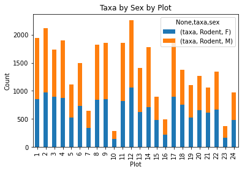

```python
plot = taxa_by_sex_by_plot.plot.bar(stacked=True, title="Taxa by Sex by Plot")
plot
plot.set_ylabel("Count")
plot.set_xlabel("Plot")
```

**Challenge - Diversity Index**

1. Use the plots.csv file that contains information about the type associated with each plot and use that data to summarize the number of plots by plot type.
2. Calculate a diversity index of your choice for control vs rodent exclosure plots. The index should consider both species abundance and number of species. You might choose to use the simple biodiversity index described here which calculates diversity as:
   - the number of species in the plot / the total number of individuals in the plot = biodiversity index

```python
plots_df = pd.read_csv('data/lab-3-data/plots.csv')
plots_df.head(10)
```

|  | plot_id | plot_type |
| --- | --- | --- |
| 0 | 1 | Spectab exclosure |
| 1 | 2 | Control |
| 2 | 3 | Long-term Krat Exclosure |
| 3 | 4 | Control |
| 4 | 5 | Rodent Exclosure |
| 5 | 6 | Short-term Krat Exclosure |
| 6 | 7 | Rodent Exclosure |
| 7 | 8 | Control |
| 8 | 9 | Spectab exclosure |
| 9 | 10 | Rodent Exclosure |

```python
merged_df = pd.merge(left=surveys_df, right=plots_df, how='left', left_on='plot_id', right_on='plot_id')
merged_df
```

|  | record_id | month | day | year | plot_id | species_id | sex | hindfoot_length | weight | plot_type |
| --- | --- | --- | --- | --- | --- | --- | --- | --- | --- | --- |
| 0 | 1 | 7 | 16 | 1977 | 2 | NL | M | 32.0 | NaN | Control |
| 1 | 2 | 7 | 16 | 1977 | 3 | NL | M | 33.0 | NaN | Long-term Krat Exclosure |
| 2 | 3 | 7 | 16 | 1977 | 2 | DM | F | 37.0 | NaN | Control |
| 3 | 4 | 7 | 16 | 1977 | 7 | DM | M | 36.0 | NaN | Rodent Exclosure |
| 4 | 5 | 7 | 16 | 1977 | 3 | DM | M | 35.0 | NaN | Long-term Krat Exclosure |
| ... | ... | ... | ... | ... | ... | ... | ... | ... | ... | ... |
| 35544 | 35545 | 12 | 31 | 2002 | 15 | AH | NaN | NaN | NaN | Long-term Krat Exclosure |
| 35545 | 35546 | 12 | 31 | 2002 | 15 | AH | NaN | NaN | NaN | Long-term Krat Exclosure |
| 35546 | 35547 | 12 | 31 | 2002 | 10 | RM | F | 15.0 | 14.0 | Rodent Exclosure |
| 35547 | 35548 | 12 | 31 | 2002 | 7 | DO | M | 36.0 | 51.0 | Rodent Exclosure |
| 35548 | 35549 | 12 | 31 | 2002 | 5 | NaN | NaN | NaN | NaN | Rodent Exclosure |

35549 rows × 10 columns

```python
merged_df[['plot_id','plot_type']]
```

|  | plot_id | plot_type |
| --- | --- | --- |
| 0 | 2 | Control |
| 1 | 3 | Long-term Krat Exclosure |
| 2 | 2 | Control |
| 3 | 7 | Rodent Exclosure |
| 4 | 3 | Long-term Krat Exclosure |
| ... | ... | ... |
| 35544 | 15 | Long-term Krat Exclosure |
| 35545 | 15 | Long-term Krat Exclosure |
| 35546 | 10 | Rodent Exclosure |
| 35547 | 7 | Rodent Exclosure |
| 35548 | 5 | Rodent Exclosure |

35549 rows × 2 columns

**Key Points from Lesson 4: Combining DataFrames with Pandas**

- Pandas’ merge and concat can be used to combine subsets of a DataFrame, or even data from different files.
- join function combines DataFrames based on index or column.
- Joining two DataFrames can be done in multiple ways (left, right, and inner) depending on what data must be in the final DataFrame.
- to_csv can be used to write out DataFrames in CSV format.

### Lesson 5: Data Workflows and Automation

**Lesson Questions**

- Can I automate operations in Python?
- What are functions and why should I use them?

**Lesson Objectives**

- Describe why for loops are used in Python.
- Employ for loops to automate data analysis.
- Write unique filenames in Python.
- Build reusable code in Python.
- Write functions using conditional statements (if, then, else).

*So far, we’ve used Python and the pandas library to explore and manipulate individual datasets by hand, much like we would do in a spreadsheet. The beauty of using a programming language like Python, though, comes from the ability to **automate data processing through the use of loops and functions**.*

```python
# Set working directory

import os
os.chdir('/Users/greg/Box/courses/umass/fall-2020/evolutionary-genomics-and-bioinformatics/evo-geno-course/')
os.getcwd()
```

```
'/Users/greg/Box/courses/umass/fall-2020/evolutionary-genomics-and-bioinformatics/evo-geno-course'
```

#### For loops

*Loops allow us to repeat a workflow (or series of actions) a given number of times or while some condition is true. We would use a loop to automatically process data that’s stored in multiple files (daily values with one file per year, for example). Loops lighten our work load by performing repeated tasks without our direct involvement and make it less likely that we’ll introduce errors by making mistakes while processing each file by hand.*

```python
animals = ['lion','tiger','crocodile','vulture','hippo']
print(animals)
```

```
['lion', 'tiger', 'crocodile', 'vulture', 'hippo']
```

```python
for creature in animals:
    print(creature)
```

```
lion
tiger
crocodile
vulture
hippo
```

*The line defining the loop must start with **for** and end with a colon, and the body of the loop must be indented.*

*In this example, **creature** is the loop variable that takes the value of the next entry in **animals** every time the loop goes around. We can call the loop variable anything we like. After the loop finishes, the loop variable will still exist and will have the value of the last entry in the collection.*

```python
animals = ['lion','tiger','crocodile','vulture','hippo']
for creature in animals:
    pass
```

```python
print('The loop variable is now: ' + creature)
```

```
The loop variable is now: hippo
```

*We are not asking Python to print the value of the loop variable anymore, but the for loop still runs and the value of **creature** changes on each pass through the loop. The statement **pass** in the body of the loop means “do nothing”.*

**Challenge - Loops**

1. What happens if we don't include the pass statement?
2. Rewrite the loop so that the animals are separated by commas, not new lines (Hint: You can concatenate strings using a plus sign. For example, print(string1 + string2) outputs 'string1string2').

```python
animals = ['lion','tiger','crocodile','vulture','hippo']
for creature in animals:
    print('The loop variable is now: ' + creature)
```

```
The loop variable is now: lion
The loop variable is now: tiger
The loop variable is now: crocodile
The loop variable is now: vulture
The loop variable is now: hippo
```

```python
animals = ['lion','tiger','crocodile','vulture','hippo']
for creature in animals:
    print(creature + ',')
```

```
lion,
tiger,
crocodile,
vulture,
hippo,
```

**Is this ^^^ correct?**

#### Automating data processing using For Loops

```python
import os
os.mkdir('data/lab-3-data/yearly_files')
```

**Note: A new folder titled 'yearly_files' was added to the directory**

```python
os.listdir('data/lab-3-data')
```

```
['bouldercreek_09_2013.txt',
 'out.csv',
 'plots.csv',
 'portal_mammals.sqlite',
 'README.txt',
 'species.csv',
 'speciesSubset.csv',
 'stack_surveys.csv',
 'surveys.csv',
 'surveys2001.csv',
 'surveys2002.csv',
 'surveys_complete.csv',
 'yearly_files']
```

**listdir function allows you to see what files/folders are in your directory**

```python
import pandas as pd

# Load the data into a DataFrame
pd.read_csv('data/lab-3-data/surveys.csv')
```

|  | record_id | month | day | year | plot_id | species_id | sex | hindfoot_length | weight |
| --- | --- | --- | --- | --- | --- | --- | --- | --- | --- |
| 0 | 1 | 7 | 16 | 1977 | 2 | NL | M | 32.0 | NaN |
| 1 | 2 | 7 | 16 | 1977 | 3 | NL | M | 33.0 | NaN |
| 2 | 3 | 7 | 16 | 1977 | 2 | DM | F | 37.0 | NaN |
| 3 | 4 | 7 | 16 | 1977 | 7 | DM | M | 36.0 | NaN |
| 4 | 5 | 7 | 16 | 1977 | 3 | DM | M | 35.0 | NaN |
| ... | ... | ... | ... | ... | ... | ... | ... | ... | ... |
| 35544 | 35545 | 12 | 31 | 2002 | 15 | AH | NaN | NaN | NaN |
| 35545 | 35546 | 12 | 31 | 2002 | 15 | AH | NaN | NaN | NaN |
| 35546 | 35547 | 12 | 31 | 2002 | 10 | RM | F | 15.0 | 14.0 |
| 35547 | 35548 | 12 | 31 | 2002 | 7 | DO | M | 36.0 | 51.0 |
| 35548 | 35549 | 12 | 31 | 2002 | 5 | NaN | NaN | NaN | NaN |

35549 rows × 9 columns

```python
# Select only data for the year 2002
surveys2002 = surveys_df[surveys_df.year == 2002]
```

```python
# Write the new DataFrame to a CSV file
surveys2002.to_csv('data/lab-3-data/yearly_files/surveys2002.csv')
```

*To create yearly data files, we could repeat the last two commands over and over, once for each year of data. Repeating code is neither elegant nor practical, and is very likely to introduce errors into your code. We want to turn what we’ve just written into a loop that repeats the last two commands for every year in the dataset.*

```python
# Get years within our DataFrame
surveys_df['year']
```

```
0        1977
1        1977
2        1977
3        1977
4        1977
         ...
35544    2002
35545    2002
35546    2002
35547    2002
35548    2002
Name: year, Length: 35549, dtype: int64
```

```python
# Get unique years within our DataFrame
surveys_df['year'].unique()
```

```
array([1977, 1978, 1979, 1980, 1981, 1982, 1983, 1984, 1985, 1986, 1987,
       1988, 1989, 1990, 1991, 1992, 1993, 1994, 1995, 1996, 1997, 1998,
       1999, 2000, 2001, 2002])
```

```python
# Now loop it...
for year in surveys_df['year'].unique():
    filename='data/yearly_files/surveys' + str(year) + '.csv'
    print(filename)
```

```
data/yearly_files/surveys1977.csv
data/yearly_files/surveys1978.csv
data/yearly_files/surveys1979.csv
data/yearly_files/surveys1980.csv
data/yearly_files/surveys1981.csv
data/yearly_files/surveys1982.csv
data/yearly_files/surveys1983.csv
data/yearly_files/surveys1984.csv
data/yearly_files/surveys1985.csv
data/yearly_files/surveys1986.csv
data/yearly_files/surveys1987.csv
data/yearly_files/surveys1988.csv
data/yearly_files/surveys1989.csv
data/yearly_files/surveys1990.csv
data/yearly_files/surveys1991.csv
data/yearly_files/surveys1992.csv
data/yearly_files/surveys1993.csv
data/yearly_files/surveys1994.csv
data/yearly_files/surveys1995.csv
data/yearly_files/surveys1996.csv
data/yearly_files/surveys1997.csv
data/yearly_files/surveys1998.csv
data/yearly_files/surveys1999.csv
data/yearly_files/surveys2000.csv
data/yearly_files/surveys2001.csv
data/yearly_files/surveys2002.csv
```

```python
# Load the data into a DataFrame
surveys_df = pd.read_csv('data/lab-3-data/surveys.csv')

for year in surveys_df['year'].unique():

    # Select data for the year
    surveys_year = surveys_df[surveys_df.year == year]

    # Write new DataFrame to CSV file
    filename = 'data/lab-3-data/yearly_files/surveys' + str(year) + '.csv'
    surveys_year.to_csv(filename)
```

#### Writing Unique File Names

```python
filename = 'data/lab-3-data/yearly_files/surveys' + str(year) + '.csv'
filename
```

```
'data/lab-3-data/yearly_files/surveys2002.csv'
```

**Challenge - Modifying Loops**

1. Some of the surveys you saved are missing data (they have null values that show up as NaN - Not A Number - in the DataFrames and do not show up in the text files). Modify the for loop so that the entries with null values are not included in the yearly files.
2. Let’s say you only want to look at data from a given multiple of years. How would you modify your loop in order to generate a data file for only every 5th year, starting from 1977?
3. Instead of splitting out the data by years, a colleague wants to do analyses each species separately. How would you write a unique CSV file for each species?

```python
# Load the data into a DataFrame
surveys_df = pd.read_csv('data/lab-3-data/surveys.csv')

for year in surveys_df['year'].unique():

    # Remove rows containing NaN values
    surveys_dropna = surveys_df.dropna()

    # Select data for the year
    surveys_year = surveys_dropna[surveys_dropna.year == year]

    # Write new DataFrame to CSV file
    filename = 'data/lab-3-data/yearly_files/dropna_surveys' + str(year) + '.csv'
    surveys_year.to_csv(filename)
```

```python
# Make sure the NaNs were effectively removed from the newly created .csv files
dropna_surveys = pd.read_csv('data/lab-3-data/yearly_files/dropna_surveys2002.csv')
dropna_surveys.isnull().sum() # No NaNs = Success!
```

```
Unnamed: 0         0
record_id          0
month              0
day                0
year               0
plot_id            0
species_id         0
sex                0
hindfoot_length    0
weight             0
dtype: int64
```

```python
# Load the data into a DataFrame
surveys_df = pd.read_csv('data/lab-3-data/surveys.csv')

for year in surveys_df['year'].unique()[0::5]:

    # Remove rows containing NaN values
    surveys_dropna = surveys_df.dropna()

    # Select data for the year
    surveys_year = surveys_dropna[surveys_dropna.year == year]

    # Write new DataFrame to CSV file
    filename = 'data/lab-3-data/yearly_files/every_5_year_surveys' + str(year) + '.csv'
    surveys_year.to_csv(filename) # The loop worked!
```

```python
# Load the data into a DataFrame
surveys_df = pd.read_csv('data/lab-3-data/surveys.csv')

for species_id in surveys_df['species_id'].unique():

    # Select data for the year
    surveys_species = surveys_df[surveys_df.species_id == species_id]

    # Write new DataFrame to CSV file
    filename = 'data/lab-3-data/yearly_files/surveys' + '_' + str(species_id) + '.csv'
    surveys_species.to_csv(filename) # The loop worked!
```

#### Building reusable and modular code with functions

*Suppose that separating large data files into individual yearly files is a task that we frequently have to perform. We could write a **for loop** like the one above every time we needed to do it but that would be time consuming and error prone. A more elegant solution would be to create a reusable tool that performs this task with minimum input from the user. To do this, we are going to turn the code we’ve already written into a function.*

*Functions are reusable, self-contained pieces of code that are called with a single command. They can be designed to accept arguments as input and return values, but they don’t need to do either. Variables declared inside functions only exist while the function is running and if a variable within the function (a local variable) has the same name as a variable somewhere else in the code, the local variable hides but doesn’t overwrite the other.*

```python
# General structure of a function
def this_is_the_function_name(input_argument1, input_argument2):

    # The body of the function is indented
    # This function prints the two arguments to screen
    print('The function arguments are:', input_argument1, input_argument2, '(this is done inside the function!)')

    # And returns their product
    return input_argument1 * input_argument2
```

```python
product_of_inputs = this_is_the_function_name(2,5)
```

```
The function arguments are: 2 5 (this is done inside the function!)
```

```python
print('Their product is:', product_of_inputs, '(this is done outside the function!)')
```

```
Their product is: 10 (this is done outside the function!)
```

**Challenge - Functions**

1. Change the values of the arguments in the function and check its output
2. Try calling the function by giving it the wrong number of arguments (not 2) or not assigning the function call to a variable (no product_of_inputs =)
3. Declare a variable inside the function and test to see where it exists (Hint: can you print it from outside the function?)
4. Explore what happens when a variable both inside and outside the function have the same name. What happens to the global variable when you change the value of the local variable?

```python
# Challenge Function 1
print('Their product is:', this_is_the_function_name(3,7), '(this is done outside the function!)')
```

```
The function arguments are: 3 7 (this is done inside the function!)
Their product is: 21 (this is done outside the function!)
```

```python
# Challenge 2
product_of_inputs = this_is_the_function_name(2)
```

```
---------------------------------------------------------------------------
TypeError                                 Traceback (most recent call last)
<ipython-input-29-409e6e171392> in <module>
----> 1 product_of_inputs = this_is_the_function_name(2)

TypeError: this_is_the_function_name() missing 1 required positional argument: 'input_argument2'
```

```python
this_is_the_function_name(2,5)
```

```
The function arguments are: 2 5 (this is done inside the function!)
```

```
10
```

**Must have both arguments ^^^**

**Challenge 3**

Not really sure what they are asking...

**Challenge 4**

Again, not really sure what they are asking...

```python
# Write a function that separates data for just one year and saves data to a file

def one_year_csv_writer(this_year, all_data):
    """
    Writes a csv file for data from a given year.

    this_year -- year for which data is extracted
    all_data -- DataFrame with multi-year data
    """

    # Select data for the year
    surveys_year = all_data[all_data.year == this_year]

    # Write the new DataFrame to a csv file
    filename = 'data/lab-3-data/yearly_files/function_surveys' + str(this_year) + '.csv'
    surveys_year.to_csv(filename)
```

```python
# returns the docstring
one_year_csv_writer?
```

```python
# creates file in folder using function
one_year_csv_writer(2002, surveys_df)
```

```python
def yearly_data_csv_writer(start_year, end_year, all_data):
    """
    Writes separate CSV files for each year of data.

    start_year -- the first year of data we want
    end_year -- the last year of data we want
    all_data -- DataFrame with mulit-year data
    """

    # "end_year" is the last year of data we want to pull, so we loop to end_year+1
    for year in range(start_year, end_year+1):
        one_year_csv_writer(year, all_data)
```

```python
# Load the data into a DataFrame
surveys_df = pd.read_csv('data/lab-3-data/surveys.csv')

# Create CSV files
yearly_data_csv_writer(1977, 2002, surveys_df)
```

**Challenge: More Functions**

1. Add two arguments to the functions we wrote that take the path of the directory where the files will be written and the root of the file name. Create a new set of files with a different name in a different directory.
2. How could you use the function yearly_data_csv_writer to create a CSV file for only one year? (Hint: think about the syntax for range)
3. Make the functions return a list of the files they have written. There are many ways you can do this (and you should try them all!): either of the functions can print to screen, either can use a return statement to give back numbers or strings to their function call, or you can use some combination of the two. You could also try using the os library to list the contents of directories.
4. Explore what happens when variables are declared inside each of the functions versus in the main (non-indented) body of your code. What is the scope of the variables (where are they visible)? What happens when they have the same name but are given different values?

```python
# Let's modify the function 'yearly_data_csv_writer'
# So that the start_year and end_year default to the full range of data
# If they are not supplied by the user

def yearly_data_arg_test(all_data, start_year=1977, end_year=2002):
    """
    Modified from yearly_data_csv_writer to test default argument values!

    start_year -- the first year of data we want (default 1977)
    end_year -- the last year of data we want (default 2002)
    all_data -- DataFrame with multi-year data

    """

    return start_year, end_year

start, end = yearly_data_arg_test(surveys_df, 1988, 1993)
print('Both optional argument:\t', start, end)

start, end = yearly_data_arg_test(surveys_df)
print('Default values:\t\t', start, end)
```

```
Both optional argument:	 1988 1993
Default values:		 1977 2002
```

**Challenge - Variables**

1. What type of object corresponds to a variable declared as None? (Hint: create a variable set to None and use the function type())
2. Compare the behavior of the function yearly_data_arg_test when the arguments have None as a default and when they do not have default values.
3. What happens if you only include a value for start_year in the function call? Can you write the function call with only a value for end_year? (Hint: think about how the function must be assigning values to each of the arguments - this is related to the need to put the arguments without default values before those with default values in the function definition!)

#### If Statements

```python
a = 5

if a < 0: # Meets first condition?

    # if a is less than zero
    print('a is a negative number')

elif a > 0: # Did not meet first condition. meets second condition?

    # if a ISN'T less than zero and IS more than zero
    print('a is a positive number')

else: # Met neither condition

    # if a ISN'T less than zero and ISN'T more than zero
    print('a must be zero')
```

```
a is a positive number
```

*The statement **elif** means “else if”, and all of the conditional statements must end in a colon.*

*As we’ve written it so far, the function **yearly_data_arg_test** associates values in the function call with arguments in the function definition just based on their order. If the function gets only two values in the function call, the first one will be associated with **all_data** and the second with **start_year**, regardless of what we intended them to be. We can get around this problem by calling the function using keyword arguments, where each of the arguments in the function definition is associated with a keyword and the function call passes values to the function using these keywords.*

```python
start, end = yearly_data_arg_test(surveys_df)
print('Default values:\t\t\t', start, end)

start, end = yearly_data_arg_test(surveys_df, 1988, 1993)
print('No keywords:\t\t\t', start, end)

start, end = yearly_data_arg_test(surveys_df, start_year=1988, end_year=1993)
print('Both keywords, in order:\t', start, end)

start, end = yearly_data_arg_test(surveys_df, end_year=1993, start_year=1988)
print('Both keywords, flipped:\t\t', start, end)

start, end = yearly_data_arg_test(surveys_df, start_year=1988)
print('One keyword, default end:\t', start, end)

start, end = yearly_data_arg_test(surveys_df, end_year=1993)
print('One keyword, default start:\t', start, end)
```

```
Default values:			 1977 2002
No keywords:			 1988 1993
Both keywords, in order:	 1988 1993
Both keywords, flipped:		 1988 1993
One keyword, default end:	 1988 2002
One keyword, default start:	 1977 1993
```

**Challenge - Modifying Functions**

**Key Points from Lesson 5: Data Workflows and Automation**

- Loops help automate repetitive tasks over sets of items.
- Loops combined with functions provide a way to process data more efficiently than we could by hand.
- Conditional statements enable execution of different operations on different data.
- Functions enable code reuse.